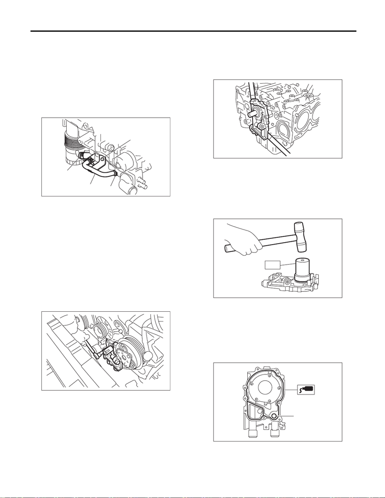

LU(STI)-13

Oil Pump

LUBRICATION

4. Oil Pump

A: REMOVAL

1) Disconnect the ground cable from battery.

2) Remove the radiator. <Ref. to CO(STI)-19, RE-

MOVAL, Radiator.>

3) Lift up the vehicle.

4) Remove the bolt (B) which secures oil cooler

pipe (A) to oil pump.

5) Remove the oil cooler pipe (A) and hose (C).

6) Lower the vehicle.

7) Remove the crankshaft position sensor.

<Ref. to FU(STI)-34, REMOVAL, Crankshaft Posi-

tion Sensor.>

8) Remove the water pump. <Ref. to CO(STI)-15,

REMOVAL, Water Pump.>

9) Remove the crank sprocket. <Ref. to ME(STI)-

61, REMOVAL, Crank Sprocket.>

10) Remove the bolts which install oil pump onto

cylinder block.

NOTE:

When disassembling and checking the oil pump,

loosen the relief valve plug before removing the oil

pump.

11) Remove the oil pump from cylinder block using

a crowbar.

CAUTION:

Be careful not to scratch mating surfaces of

cylinder block and oil pump.

12) Remove the front oil seal from the oil pump.

B: INSTALLATION

1) Using the ST, install the front oil seal.

ST 499587100 OIL SEAL INSTALLER

NOTE:

Use a new front oil seal.

2) Apply liquid gasket to the mating surfaces of oil

pump.

NOTE:

Install within 5 min. after applying liquid gasket.

Liquid gasket:

THREE BOND 1217G (Part No. K0877Y0100)

or equivalent

LU-02396

(B)

(C)

(C)

(A)

LU-00015

(A) O-ring

LU-03222

LU-00021

ST

ME-00165

(A)

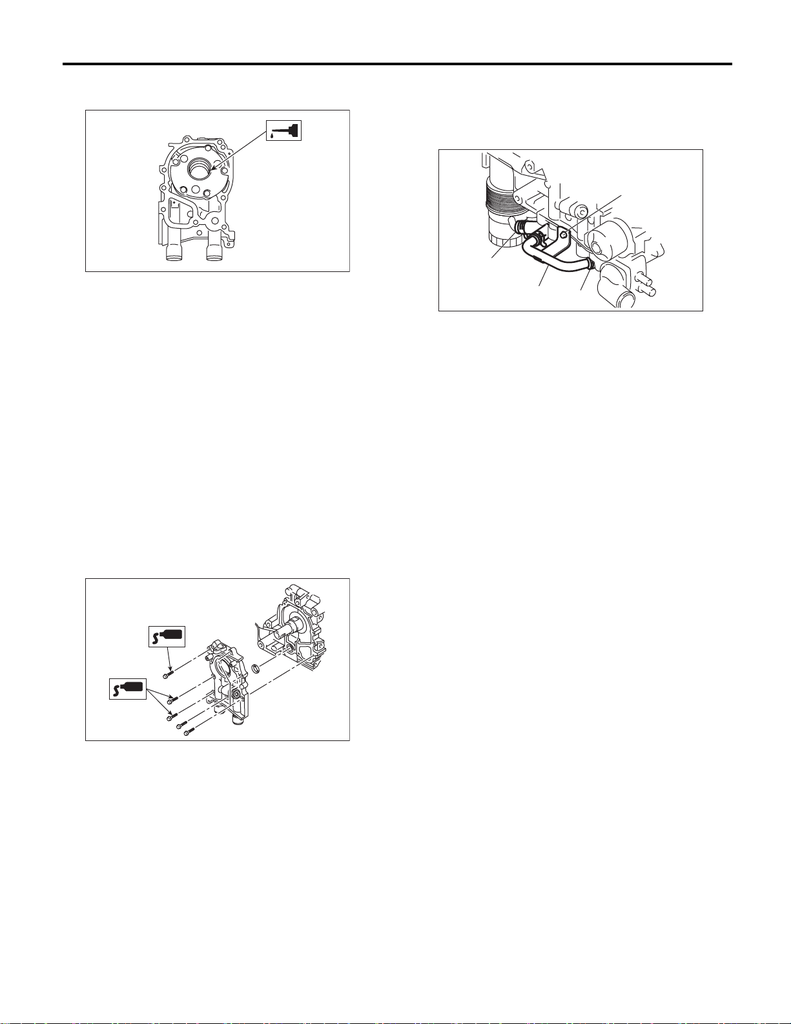

LU(STI)-14

Oil Pump

LUBRICATION

3) Apply a coat of engine oil to the inside of front oil

seal.

4) Install the oil pump to cylinder block.

CAUTION:

• Be careful not to damage the front oil seal

during installation.

• Make sure the front oil seal lip is not folded.

NOTE:

• Align the flat surface of oil pump’s inner rotor with

that of crankshaft before installation.

• Use new O-rings.

• Do not forget to install O-rings.

5) Apply liquid gasket to the three bolts thread

shown in figure. (when reusing bolts)

Liquid gasket:

THREE BOND 1324 (Part No. 004403042) or

equivalent

Tightening torque:

6.4 N·m (0.7 kgf-m, 4.7 ft-lb)

6) Install the crank sprocket. <Ref. to ME(STI)-61,

INSTALLATION, Crank Sprocket.>

7) Install the water pump. <Ref. to CO(STI)-15, IN-

STALLATION, Water Pump.>

8) Install the crankshaft position sensor. <Ref. to

FU(STI)-34, INSTALLATION, Crankshaft Position

Sensor.>

9) Lift up the vehicle.

10) Install oil cooler pipe (A) and hose (C).

11) Install the oil cooler pipe (A) to oil pump using

the bolts (B).

Tightening torque:

6.4 N·m (0.7 kgf-m, 4.7 ft-lb)

12) Lower the vehicle.

13) Install the radiator. <Ref. to CO(STI)-20, IN-

STALLATION, Radiator.>

14) Connect the battery ground terminal.

ME-00312

ME-04946

LU-02396

(B)

(C)

(C)

(A)

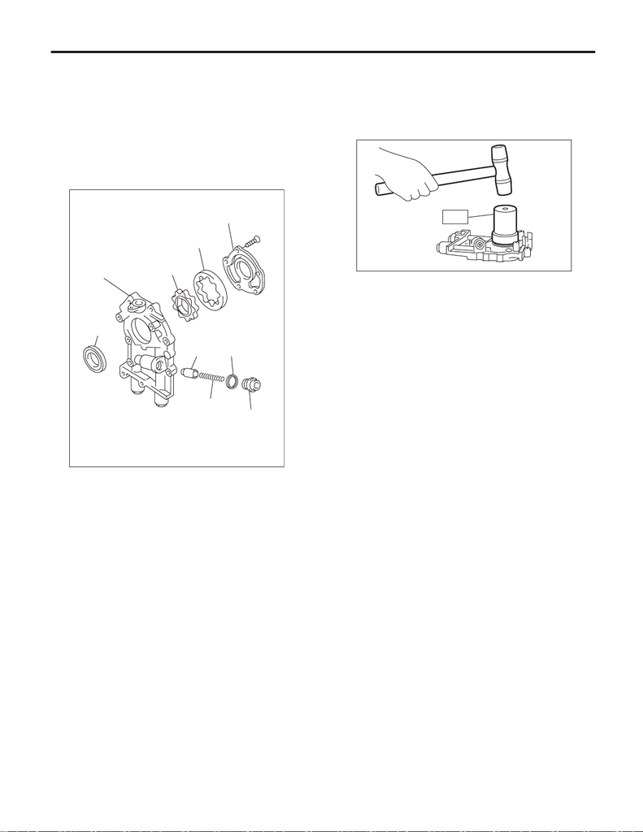

LU(STI)-15

Oil Pump

LUBRICATION

C: DISASSEMBLY

Remove the screw which secures oil pump cover

and then disassemble oil pump. Inscribe alignment

marks on the inner rotor and outer rotor so that they

can be replaced in their original positions during re-

assembly.

NOTE:

Before disassembling the oil pump, remove the re-

lief valve.

D: ASSEMBLY

1) Using the ST, install the front oil seal.

ST 499587100 OIL SEAL INSTALLER

NOTE:

Use a new front oil seal.

2) Apply a coat of engine oil to the inner rotor and

outer rotor.

3) Install the inner rotor and outer rotor.

4) Assemble the oil relief valve and install relief

valve spring and plug.

NOTE:

Use a new gasket.

(A) Front oil seal

(B) Oil pump case

(C) Inner rotor

(D) Outer rotor

(E) Oil pump cover

(F) Relief valve

(G) Relief valve spring

(H) Plug

(I) Gasket

LU-00020

(E)

(D)

(C)

(B)

(A)

(F)

(G)

(I)

(H)

LU-00021

ST

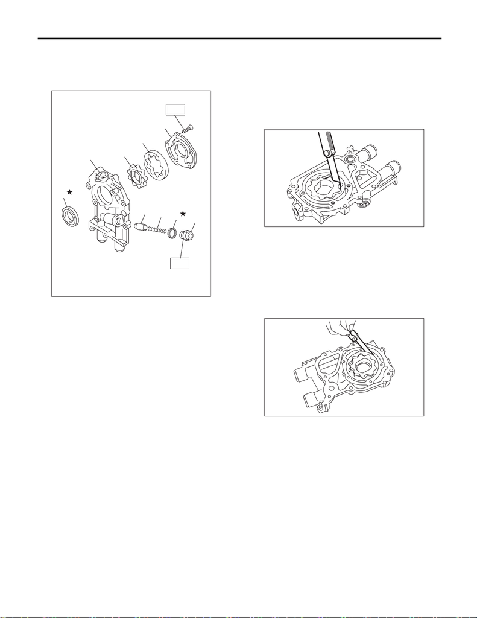

LU(STI)-16

Oil Pump

LUBRICATION

5) Install the oil pump cover.

Tightening torque:

T1: 5.4 N·m (0.6 kgf-m, 4.0 ft-lb)

T2: 44 N·m (4.5 kgf-m, 32.5 ft-lb)

E: INSPECTION

1. TIP CLEARANCE

Measure the tip clearance of rotors. If the clearance

is out of standard, replace the rotors as a set.

Tip clearance between inner and outer rotors:

Standard

0.04 — 0.14 mm (0.0016 — 0.0055 in)

2. CASE CLEARANCE

Measure the clearance between outer rotor and oil

pump case. If clearance exceeds the standard, re-

place the oil pump case.

Case clearance between outer rotor and pump

case:

Standard

0.10 — 0.175 mm (0.0039 — 0.0069 in)

(A) Front oil seal

(B) Oil pump case

(C) Inner rotor

(D) Outer rotor

(E) Oil pump cover

(F) Relief valve

(G) Relief valve spring

(H) Plug

(I) Gasket

LU-02134

T1

T2

(G)

(F)

(I)

(H)

(A)

(B)

(C)

(D)

(E)

LU-00023

LU-00024

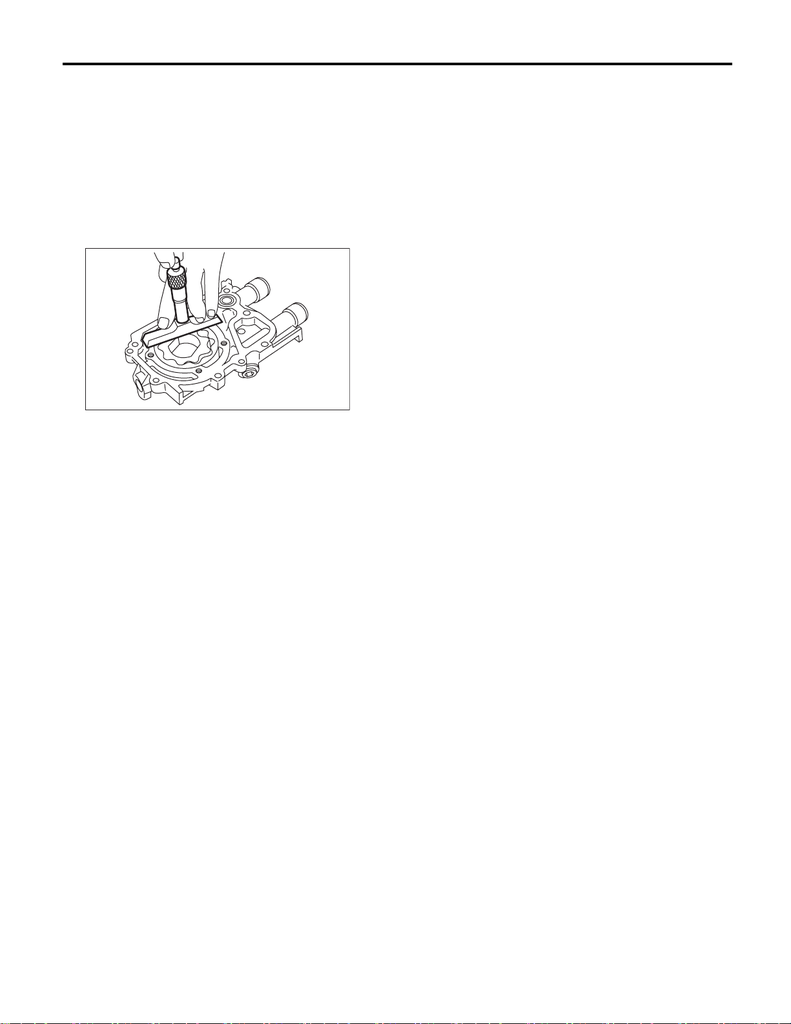

LU(STI)-17

Oil Pump

LUBRICATION

3. SIDE CLEARANCE

Measure the gap between the inner rotor and the

oil pump case to measure the clearance between

the inner rotor and the oil pump cover as shown in

the figure. If clearance is out of standard, replace

the rotor or the oil pump case.

Side clearance between inner rotor and pump

case:

Standard

0.02 — 0.07 mm (0.0008 — 0.0028 in)

4. OIL RELIEF VALVE

Check the valve for assembly condition and dam-

age, and the relief valve spring for damage and de-

terioration.

Replace the parts if defective.

Relief valve spring:

Free length

73.7 mm (2.902 in)

Installed length

54.7 mm (2.154 in)

Load when installed

93.1 N (9.49 kgf, 20.93 lbf)

5. OIL PUMP CASE

Check for worn shaft hole, clogged oil passage,

worn rotor chamber, cracks and other faults.

6. FRONT OIL SEAL

Check the front oil seal lips for deformation, hard-

ening, wear, etc. and replace if defective.

LU-00025